# Proteome-wide Screen for RNA-dependent Proteins in Non-Synchronized HeLa cells

Alisa Kirkin, Sina Kühnel, Ignacio Lozano Onrubia, Greta Pick

19/07/2022

# Final Report

# 1. Introduction

Cancer, neurological diseases and muscular atrophy - What do these diseases have in common? All of them include RNA-binding proteins. RNA-binding proteins (RBP) are proteins that bind RNA and form ribonucleoprotein particles. They are involved in a number of processes like translation, alternative splicing, RNA editing and chemical modification as well as protein modification. RBPs belong to the RNA-dependent proteins (RDP) togehter with RBP-binding proteins. These RBP-binding proteins bind RBPs when they assemble with RNA. Their complex interactions are crucial for cellular functions and therefore it is of importance to identify RDPs.

## 1.1 Summary of experiment

To identify RDPs HeLa S3 cels in different cell cycle stages were lysed. The cell lysate was split into a control and an RNase gropup. The RNase gropu was treated with RNase which causes the degradation of RNase. RBPs can no longer bind to RNA and RBP-binding proteins to RBPs. The control group did not receive any further treatment and therefore all RNA and RDPs interact. The cell lysate was transferred onto a sucrose density gradient. After ultra centrifugation the RNA-protein complexes or proteins alone will end up in one of 25 fractions depending on their molecular weight. A heavy RNA-protein complex will travel further and land in a higher fraction than one protein alone.

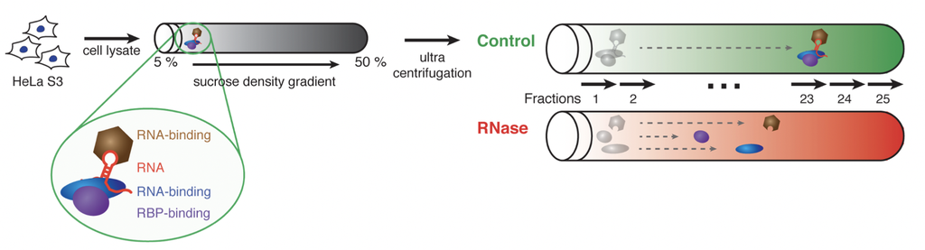

*Figure 1*: Generation of Data.

## 1.2 Goals

Automatic dentification of RNA-dependent proteins based on fraction shift.

# 2. Description of the Dataset

# 3. Data Clean Up and Normalization

# 3.1 Data Clean Up

## 3.3 Scaling

# 4. Maxima and Gaussian Curve

## 4.1 Smoothing the Curve

## 4.2 Identification of global Maxima

## 4.3 Gauss fitting to the Curve